# Bayesian Meta-analysis QRS

Omar Abdullah Gill

10/04/2026

We loaded all required packages and libraries

```r
pacman::p_load(bayesmeta,          # Bayesian Meta-Analysis
               BayesianPriorsTool, # Priors Building Tool
               dplyr,              # Data Wrangle
               tidyr,              # Data Wrangle
               meta,               # Forest Plot
               metafor,            # Effect Sizes
               ggdist,             # Distributions
               ggplot2,            # Plots
               patchwork,          # Plots
               here,
               readxl,             # Import data
               gt)

# ggplot2 theme
theme_set(
  theme(
    plot.title.position = 'plot',
    axis.ticks.x = element_blank(),
    axis.ticks.y = element_blank(),
    axis.text.x = element_text(size = 12),
    axis.text.y = element_text(size = 12),
    axis.title.x = element_text(size = 14),
    panel.background = element_blank(),
    panel.grid.major.x = element_line(color = "gray80", linewidth = 0.3)
  )
)
```

We input Mean, SD, and N for Conduction System Pacing (CSP) and Biventricular Pacing (BVP). We calculate the Mean Difference (MD) using ‘escalc’, providing a linear scale in milliseconds (ms) suitable for absolute QRS analysis.

```r
qrs_data <- data.frame(
study = c("Huang, 2022", "Lustgarten, 2015", "Upadhyay, 2019", "Vinther, 2021",

            "Pujol-Lopez, 2022", "Vijayaraman, 2023", "Wang, 2022", "PhysioSync-HF Trial, 2026"),
subgroup = c("HBP", "HBP", "HBP", "HBP", "LBAP", "LBAP", "LBAP", "LBAP"),

  # CSP (Conduction System Pacing)
m1 = c(107.7, 145.0, 125.0, 134.0, 125.0, 137.0, 131.5, 122.0),
sd1 = c(12.5, 24.0, 22.0, 15.0, 18.0, 20.0, 12.5, 25.0),
n1 = c(50, 21, 16, 25, 35, 50, 20, 87),
  # BVP (Biventricular Pacing)
m2 = c(135.7, 165.0, 164.0, 131.0, 129.0, 141.0, 136.6, 126.0),
sd2 = c(16.6, 17.0, 25.0, 20.0, 13.0, 19.0, 12.9, 21.0),
n2 = c(50, 21, 24, 25, 35, 50, 20, 86)

)
# Calculate Mean Difference (MD) and Variance (vi)

dat_MD_qrs <- escalc(measure = "MD",

                     m1i = m1, sd1i = sd1, n1i = n1,

                     m2i = m2, sd2i = sd2, n2i = n2,

                     data = qrs_data) |>
data.frame()

# Calculate Standard Error (sei) from Variance (vi)
dat_MD_qrs$sei <- sqrt(dat_MD_qrs$vi)

# View the analyzed dataset
print(dat_MD_qrs[, c("study", "subgroup", "yi", "vi", "sei")])
```

```
##                       study subgroup    yi       vi      sei
## 1               Huang, 2022      HBP -28.0  8.63620 2.938741
## 2          Lustgarten, 2015      HBP -20.0 41.19048 6.417981
## 3            Upadhyay, 2019      HBP -39.0 56.29167 7.502777
## 4             Vinther, 2021      HBP   3.0 25.00000 5.000000
## 5         Pujol-Lopez, 2022     LBAP  -4.0 14.08571 3.753094
## 6         Vijayaraman, 2023     LBAP  -4.0 15.22000 3.901282
## 7                Wang, 2022     LBAP  -5.1 16.13300 4.016591
## 8 PhysioSync-HF Trial, 2026     LBAP  -4.0 12.31182 3.508820
```

Models

## Subgroup model

$$\begin{align*}
y_i&\sim Normal(\theta_i, \sigma_i^2)\\
\theta_i &\sim Normal(\mu, \tau^2) \\
\mu &= \alpha_{0} + \beta x_i\\
\\
Data: \\
y_i &= \text{study i's mean effect size} \\
\sigma_i &= \text{study i's effect size standard error}\\
x &= \text{binary indicator if study i corresponds to subgroup 0 or
1}
\\
\text{Parameters:} \\
\alpha_0 & = \text{overall effect in subgroup 0} \\
\beta &= \text{difference between subgroups} \\
\tau & = \text{between-study heterogeneity} \\
\\
\text{Estimands:} \\
\alpha_0 & = \text{overall effect in subgroup 0} \\
\alpha_0 + \beta & = \text{overall effect in subgroup 1} \\
\end{align*}$$

Priors (Vague)

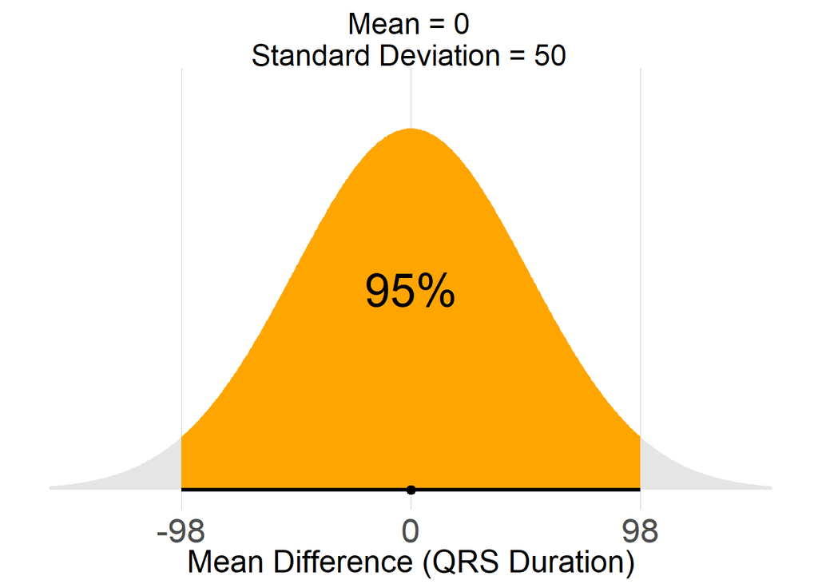

```r
# Mean = 0, SD = 50 (Vague/Broad)

prior_mu_vague_mean_qrs=0
prior_mu_vague_sd_qrs= 50

mu_dist_viz(mean   = prior_mu_vague_mean_qrs,
            sd     = prior_mu_vague_sd_qrs,
            scale  = "absolute",
            xlabel = "Mean Difference (QRS Duration)")
```

Beta: the subgroup difference - Weakly-informative prior

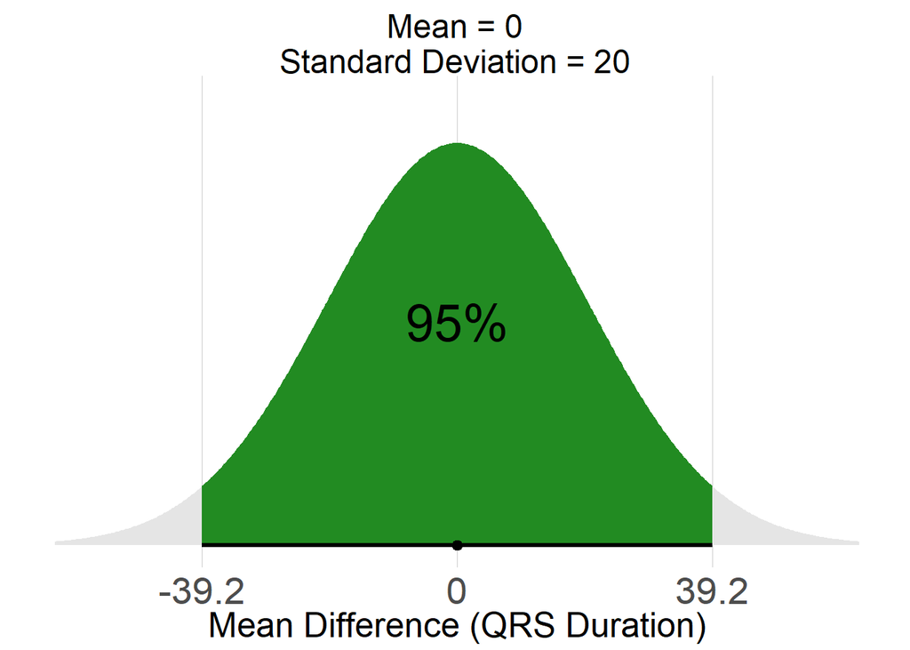

```r
#Coefficient Priors (beta) ---

# Intercept (HBP) and Slope (LBAP difference)
prior_beta_weakly_mean = 0
prior_beta_weakly_sd = 20

mu_dist_viz(mean = prior_beta_weakly_mean,
            sd = prior_beta_weakly_sd,
            scale = "absolute",
            xlabel = "Mean Difference (QRS Duration)",
            inner_color = "forestgreen")
```

#Priors

How we derive informative prior for tau

The prior for between-study heterogeneity (τ) was specified using a weakly informative half-normal distribution.

To calibrate this prior, we elicited a treatment effect size of 13.34 ms based on the observed range of effects from a previuos meta. Assuming that this value represents the 97.5th percentile of the distribution of true study-level effects, we first converted it to the corresponding heterogeneity scale and then derived the scale parameter of the half-normal prior using a standard two-stage normal calibration approach.

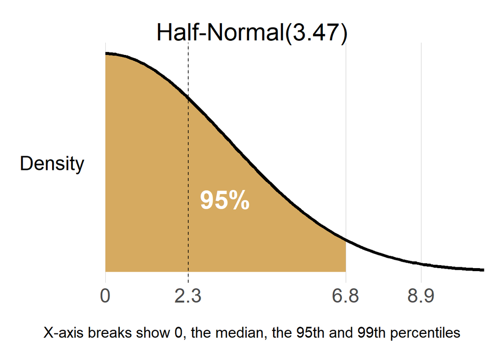

```r
infor_prior_MD_scale_qrs = 13.34
tau_prior_plot(infor_prior_MD_scale_qrs)
```

```r
prior_infor_tau_main_qrs = function(x) dhalfnormal(x, scale = infor_prior_MD_scale_qrs)
```

This yielded a prior scale of τ ~ Half-Normal(0, 3.47), which reflects substantial uncertainty while constraining implausibly large between-study heterogeneity.

tau (weakly informative)

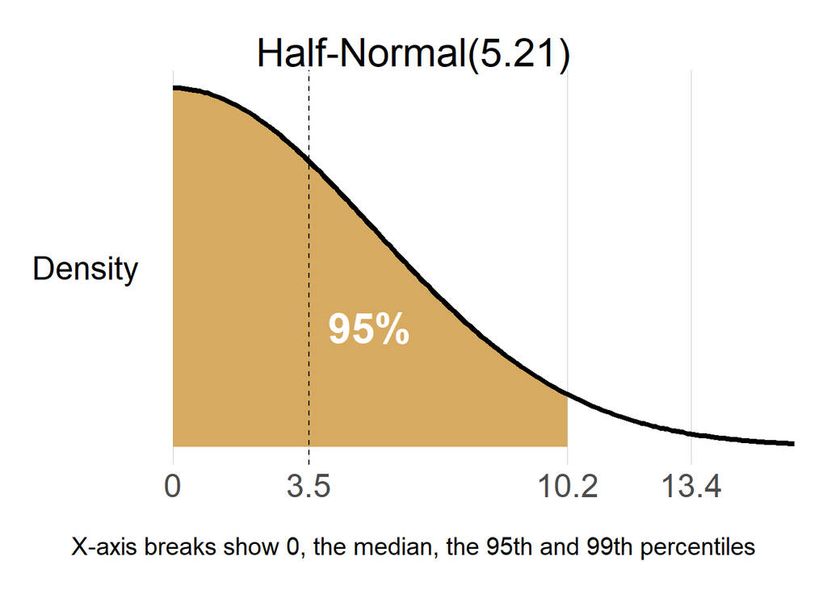

```r
weakly_prior_MD_scale_qrs = 20
tau_prior_plot(weakly_prior_MD_scale_qrs)
```

```r
prior_weakly_tau_main_qrs = function(x) dhalfnormal(x, scale = weakly_prior_MD_scale_qrs)
```

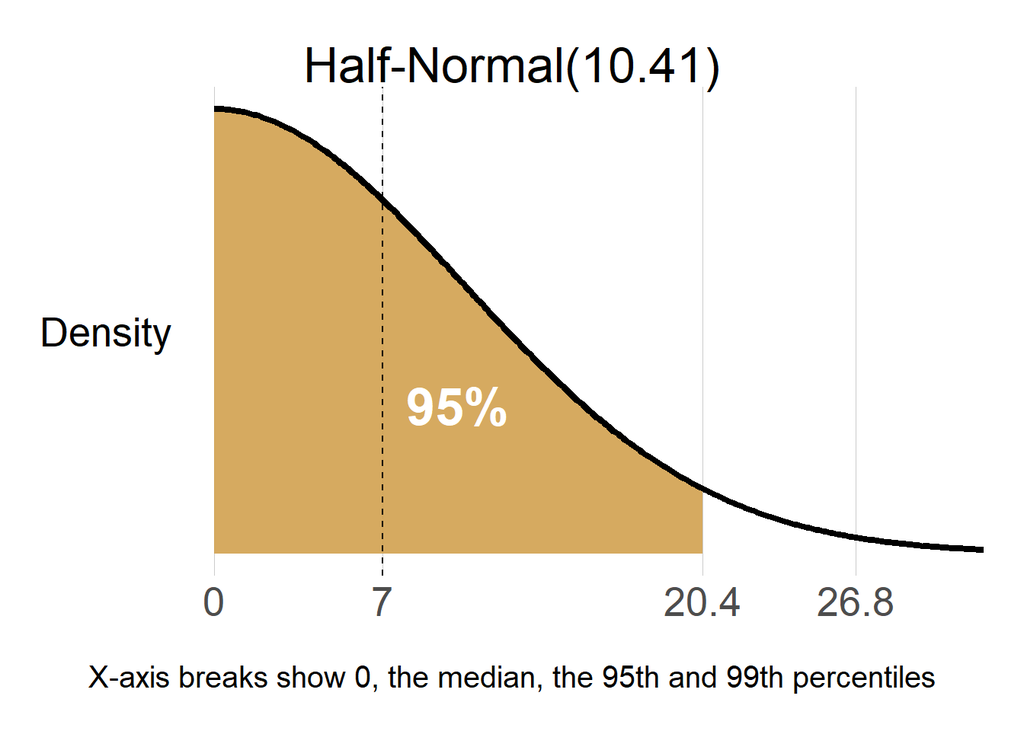

```r
vague_prior_MD_scale_qrs = 40
tau_prior_plot(vague_prior_MD_scale_qrs)
```

```r
prior_vague_tau_main_qrs = function(x) dhalfnormal(x, scale = vague_prior_MD_scale_qrs)
```

# Main primary subgroups analysis

```r
qrs_priors_means_main = c(prior_mu_vague_mean_qrs, prior_beta_weakly_mean)
qrs_priors_sd_main    = c(prior_mu_vague_sd_qrs, prior_beta_weakly_sd)
#subgroups
dat_MD_qrs$subgroup = factor(dat_MD_qrs$subgroup,
                             levels = c("HBP", "LBAP"))

# Create the model matrix for the regression
# This creates an Intercept (HBP) and a coefficient for LBAP
matrix_qrs_subgroups = stats::model.matrix(~subgroup, data = dat_MD_qrs)
# Execute the model
main_subgroup_qrs_model = bmr(

y      = dat_MD_qrs$yi,            # Mean Difference (ms)
sigma  = dat_MD_qrs$sei,           # Standard Error
labels = dat_MD_qrs$study,
X      = matrix_qrs_subgroups,     # Matrix identifying HBP vs LBAP
beta.prior.mean = qrs_priors_means_main,
beta.prior.sd   = qrs_priors_sd_main,
tau.prior = prior_infor_tau_main_qrs

)
```

# Subgroup Sensitivity

Subgroup (Vague+weakly-informative)

```r
subgroup_sensitivity_weakly_model = bmr(

y      = dat_MD_qrs$yi,            # Mean Difference (ms)
sigma  = dat_MD_qrs$sei,           # Standard Error
labels = dat_MD_qrs$study,
X      = matrix_qrs_subgroups,     # Matrix identifying HBP vs LBAP
beta.prior.mean = qrs_priors_means_main,
beta.prior.sd   = qrs_priors_sd_main,
tau.prior = prior_weakly_tau_main_qrs

)
```

Subgroup (Vague+Vague)

```r
subgroup_sensitivity_vague_model = bmr(

y      = dat_MD_qrs$yi,            # Mean Difference (ms)
sigma  = dat_MD_qrs$sei,           # Standard Error
labels = dat_MD_qrs$study,
X      = matrix_qrs_subgroups,     # Matrix identifying HBP vs LBAP
beta.prior.mean = qrs_priors_means_main,
beta.prior.sd   = qrs_priors_sd_main,
tau.prior = prior_vague_tau_main_qrs

)
```

Overall Main analysis

```r
model_qrs_primary = bayesmeta(
  y      = dat_MD_qrs$yi,           # Mean Difference from escalc
  sigma  = dat_MD_qrs$sei,          # Standard Error from escalc
  labels = dat_MD_qrs$study,        # Study Names

  # Applying the synchronized priors
  mu.prior.mean = prior_mu_vague_mean_qrs,
  mu.prior.sd   = prior_mu_vague_sd_qrs,
  tau.prior     = prior_infor_tau_main_qrs
)

# 5. Review Results
summary(model_qrs_primary)
```

```
##  'bayesmeta' object.
## data (8 estimates):
##                               y    sigma
## Huang, 2022               -28.0 2.938741
## Lustgarten, 2015          -20.0 6.417981
## Upadhyay, 2019            -39.0 7.502777
## Vinther, 2021               3.0 5.000000
## Pujol-Lopez, 2022          -4.0 3.753094
## Vijayaraman, 2023          -4.0 3.901282
## Wang, 2022                 -5.1 4.016591
## PhysioSync-HF Trial, 2026  -4.0 3.508820
##
## tau prior (proper):
## function (x)
## dhalfnormal(x, scale = infor_prior_MD_scale_qrs)
## <bytecode: 0x00000213f18025e0>
##
## mu prior (proper):
## normal(mean=0, sd=50)
##
## ML and MAP estimates:
##                   tau        mu
## ML joint     12.05490 -11.98552
## ML marginal  13.09556 -11.85682
## MAP joint    11.30242 -11.83189
## MAP marginal 12.09927 -11.76154
##
## marginal posterior summary:
##                 tau         mu     theta
## mode      12.099269 -11.761539 -11.73260
## median    13.251582 -11.856400 -11.84918
## mean      13.871827 -11.899520 -11.89952
## sd         4.138107   5.354214  15.45696
## 95% lower  6.816163 -22.691195 -43.11366
## 95% upper 22.204634  -1.238379  19.16257
##
## (quoted intervals are shortest credible intervals.)
##
## Bayes factors:
##                tau=0       mu=0
## actual  2.146680e-10 0.70569066
## minimum 7.536654e-11 0.06659283
##
## relative heterogeneity I^2 (posterior median): 0.9099878
```

# Sensitivity Overall

Overall (Vague + Weakly sensitivity)

```r
weakly_sensitivity_overall_model = bayesmeta(
  y      = dat_MD_qrs$yi,           # Mean Difference from escalc
  sigma  = dat_MD_qrs$sei,          # Standard Error from escalc
  labels = dat_MD_qrs$study,        # Study Names

  # Applying the synchronized priors
  mu.prior.mean = prior_mu_vague_mean_qrs,
  mu.prior.sd   = prior_mu_vague_sd_qrs,
  tau.prior     = prior_weakly_tau_main_qrs
)
```

Overall (Vague+Vague)

```r
vague_sensitivity_overall_model = bayesmeta(
  y      = dat_MD_qrs$yi,           # Mean Difference from escalc
  sigma  = dat_MD_qrs$sei,          # Standard Error from escalc
  labels = dat_MD_qrs$study,        # Study Names

  # Applying the synchronized priors
  mu.prior.mean = prior_mu_vague_mean_qrs,
  mu.prior.sd   = prior_mu_vague_sd_qrs,
  tau.prior     = prior_vague_tau_main_qrs
)
```

# Results of Bayesian meta-analysis

## Primary analysis

Forest plot

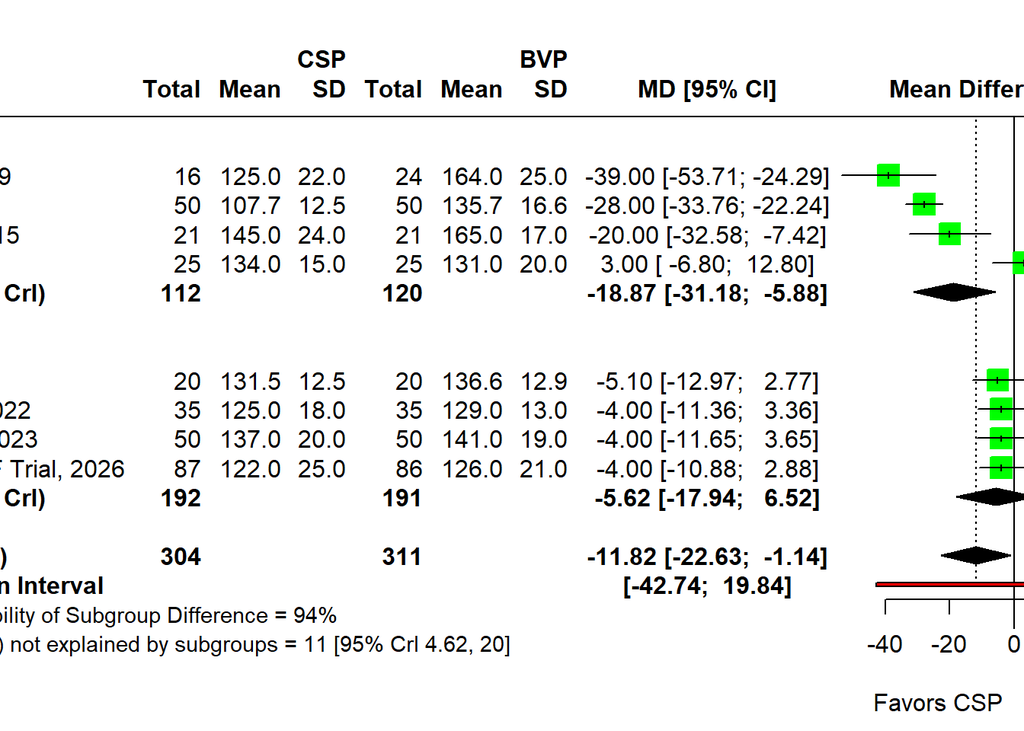

```r
set.seed(123)
subgroup_samples =
  main_subgroup_qrs_model$rposterior(n = 10000, tau.sample = FALSE) |>
  data.frame() |>
  reframe(HBP = `X.Intercept.`,
          LBAP = `X.Intercept.` + subgroupLBAP) # Adjust to your slope name

# Get the mean and 95% CrI for each subgroup
subgroupHBP_summary = subgroup_samples$HBP |> mean_hdi()

subgroupLBAP_summary = subgroup_samples$LBAP |> mean_hdi()

posterior_subgroup_qrs_model =
  data.frame(
    subgroupHBP_mean = subgroupHBP_summary$y,
    subgroupHBP_upper = subgroupHBP_summary$ymax,
    subgroupHBP_lower = subgroupHBP_summary$ymin,

    subgroupLBAP_mean = subgroupLBAP_summary$y,
    subgroupLBAP_upper = subgroupLBAP_summary$ymax,
    subgroupLBAP_lower = subgroupLBAP_summary$ymin,

    tau_median = main_subgroup_qrs_model$summary["median","tau"],
    tau_upper = main_subgroup_qrs_model$summary["95% upper","tau"],
    tau_lower = main_subgroup_qrs_model$summary["95% lower","tau"]
  )

# 2. Extract Posterior Samples from OVERALL Model (model_qrs_primary) -----
# This ensures the 'Total' diamond matches your primary analysis
overall_samples =
  model_qrs_primary$rposterior(n = 10000, tau.sample = FALSE)

prediction_samples =
  model_qrs_primary$rposterior(n = 10000, tau.sample = FALSE, predict = TRUE)

overall_summary_qrs = overall_samples |> mean_hdi()
prediction_summary_qrs = prediction_samples |> mean_hdi()

# 3. Create Forest Plot Object
forest_data_MD = metacont(
  data = dat_MD_qrs,
  subgroup = subgroup,
  studlab = study,
  mean.e = m1, sd.e = sd1, n.e = n1, # CSP
  mean.c = m2, sd.c = sd2, n.c = n2, # BVP
  sm = "MD", common = FALSE, random = FALSE
)

# 4. Add the Overall Bayesian Results
m1_qrs = metaadd(forest_data_MD,
                 type = "random", text = "Overall Results",
                 TE = overall_summary_qrs$y,
                 lower = overall_summary_qrs$ymin,
                 upper = overall_summary_qrs$ymax)

# Manually insert subgroup-specific results (Subtotals)
m1_qrs$TE.random.w = c(posterior_subgroup_qrs_model$subgroupHBP_mean,
                       posterior_subgroup_qrs_model$subgroupLBAP_mean)

m1_qrs$lower.random.w = c(posterior_subgroup_qrs_model$subgroupHBP_lower,
                          posterior_subgroup_qrs_model$subgroupLBAP_lower)

m1_qrs$upper.random.w = c(posterior_subgroup_qrs_model$subgroupHBP_upper,
                          posterior_subgroup_qrs_model$subgroupLBAP_upper)

# Name the subtotals
names(m1_qrs$TE.random.w) <- names(m1_qrs$lower.random.w) <-
  names(m1_qrs$upper.random.w) <-  c("HBP", "LBAP")

# Add the Overall Prediction Interval
m1_qrs_predict = metaadd(
  m1_qrs,
  type = "prediction",
  TE = prediction_summary_qrs$y,
  upper = prediction_summary_qrs$ymax,
  lower = prediction_summary_qrs$ymin
)

# 5. Calculation of Subgroup Probabilities
prob_lower_than_0 = main_subgroup_qrs_model$pposterior(which.beta = 2, beta = 0)
prob_greater_than_0 = 1 - prob_lower_than_0
chosen_prob_qrs = max(prob_lower_than_0, prob_greater_than_0)

subgroup_diff_text =
  paste0("Posterior Probability of Subgroup Difference = ",
         round(chosen_prob_qrs, 3)*100, "%")

tau_subgroups_text =
  paste0("Heterogeneity (\u03C4) not explained by subgroups = ",
         round(posterior_subgroup_qrs_model$tau_median, 2),
         " [95% CrI ",
         round(posterior_subgroup_qrs_model$tau_lower, 2),
         ", ",
         round(posterior_subgroup_qrs_model$tau_upper, 2), "]")

# 6. Final Plotting
forest(m1_qrs_predict,
       layout = "RevMan5",
       sortvar = TE,
       text.random = "Total (95% CrI)",
       text.predict = "95% Prediction Interval",
       text.random.w = "Subtotal (95% CrI)",
       col.subgroup = "black",
       print.subgroup.name = FALSE,
       hetstat = FALSE,
       test.subgroup = FALSE,

       text.addline1 = subgroup_diff_text,
       text.addline2 = tau_subgroups_text,

       lab.e = "CSP", lab.c = "BVP",
       label.left = "Favors CSP", label.right = "Favors BVP",

       smlab = "Mean Difference (ms)",
       leftcols = c("studlab", "n.e", "mean.e", "sd.e", "n.c", "mean.c", "sd.c", "effect.ci"),
       digits.mean = 1, digits.sd = 1, colgap = "3mm")
```

Probability plots

We extract posterior samples for subgroups and overall. These will be visualized as half-eye density plots and cumulative probability curves to illustrate uncertainty and probability of treatment effects.

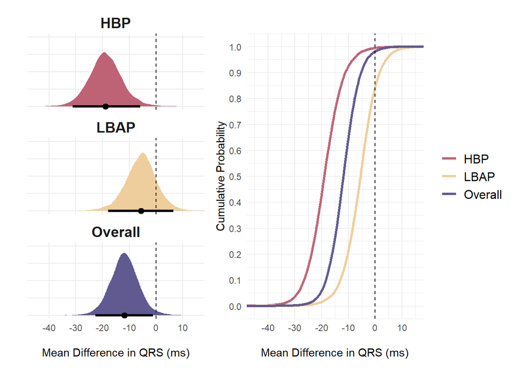

```r
# Important to set seed to assure reproducibility
set.seed(123)
# 1. Extract Posterior Samples
# Using your subgroup model and overall model objects
subgroup_samples_qrs =
  main_subgroup_qrs_model$rposterior(n = 10000, tau.sample = FALSE) |>
  data.frame() |>
  reframe(
    HBP = `X.Intercept.`,                # Intercept = HBP
    LBAP = `X.Intercept.` + subgroupLBAP # Intercept + Slope = LBAP
  )
# Extract samples for overall model
overall_samples_qrs = model_qrs_primary$rposterior(n = 10000, tau.sample = FALSE)

# Combine into one data frame
combined_samples_qrs = subgroup_samples_qrs |>
  mutate(Overall = overall_samples_qrs)

# 2. Density Plot (Half-Eye)
density_plot_qrs =
  combined_samples_qrs |>
  pivot_longer(everything()) |>
  mutate(name = factor(name, levels = c("HBP", "LBAP", "Overall"))) |>
  ggplot(aes(x = value, fill = name)) +
  # Shows distribution + Mean + 95% HDI
  stat_halfeye(.width = 0.95, point_interval = mean_hdi) +
  scale_fill_manual(values = c("#BE6376", "#EECE9C", "#605A91")) +
  geom_vline(xintercept = 0, linetype = "dashed", color = "black") + # Reference is 0ms
  scale_x_continuous(breaks = seq(-40, 20, 10)) +
  coord_cartesian(xlim = c(-45, 15)) +
  labs(x = "\nMean Difference in QRS (ms)", y = "") +
  facet_wrap(~name, ncol = 1) +
  theme_minimal() +
  theme(axis.text.y = element_blank(),
        legend.position = "none",
        strip.text.x = element_text(size = 14, face = "bold"),
        panel.grid.minor = element_blank())

# 3. ECDF (Cumulative Probability) Plot
probability_plot_qrs =
  combined_samples_qrs |>
  pivot_longer(everything()) |>
  mutate(name = factor(name, levels = c("HBP", "LBAP", "Overall"))) |>
  ggplot(aes(x = value, colour = name)) +
  geom_line(aes(y = after_stat(y)), stat = 'ecdf', linewidth = 1.2) +
  scale_color_manual(values = c("#BE6376", "#EECE9C", "#605A91")) +
  geom_vline(xintercept = 0, linetype = "dashed", color = "black") +
  scale_x_continuous(breaks = seq(-40, 20, 10)) +
  scale_y_continuous(breaks = seq(0, 1, 0.1), name = "Cumulative Probability") +
  coord_cartesian(xlim = c(-45, 15)) +
  labs(x = "\nMean Difference in QRS (ms)") +
  theme_minimal() +
  theme(panel.grid.major.y = element_line(color = "gray90", linewidth = 0.3),
        legend.text = element_text(size = 12),
        legend.title = element_blank())

# 4. Combine Plots
density_plot_qrs + probability_plot_qrs
```

Sensitivity Analysis

```r
set.seed(123)
# POSTERIOR: MAIN MODEL
subgroup_samples_main =
  main_subgroup_qrs_model$rposterior(n = 10000, tau.sample = FALSE) |>
  data.frame() |>
  reframe(
    HBP = `X.Intercept.`,
    LBAP = `X.Intercept.` + subgroupLBAP
  )

subgroupHBP_main = subgroup_samples_main$HBP |> mean_hdi()
subgroupLBAP_main = subgroup_samples_main$LBAP |> mean_hdi()

posterior_main =
  data.frame(
    HBP_mean = subgroupHBP_main$y,
    HBP_lower = subgroupHBP_main$ymin,
    HBP_upper = subgroupHBP_main$ymax,

    LBAP_mean = subgroupLBAP_main$y,
    LBAP_lower = subgroupLBAP_main$ymin,
    LBAP_upper = subgroupLBAP_main$ymax
  )


# POSTERIOR: SENSITIVITY MODEL (Weakly)
subgroup_samples_sens =
  subgroup_sensitivity_weakly_model$rposterior(n = 10000, tau.sample = FALSE) |>
  data.frame() |>
  reframe(
    HBP = `X.Intercept.`,
    LBAP = `X.Intercept.` + subgroupLBAP
  )

subgroupHBP_sens = subgroup_samples_sens$HBP |> mean_hdi()
subgroupLBAP_sens = subgroup_samples_sens$LBAP |> mean_hdi()

posterior_sens_weak =
  data.frame(
    HBP_mean = subgroupHBP_sens$y,
    HBP_lower = subgroupHBP_sens$ymin,
    HBP_upper = subgroupHBP_sens$ymax,

    LBAP_mean = subgroupLBAP_sens$y,
    LBAP_lower = subgroupLBAP_sens$ymin,
    LBAP_upper = subgroupLBAP_sens$ymax
  )

# POSTERIOR: SENSITIVITY MODEL (Vague)
subgroup_samples_sens =
  subgroup_sensitivity_vague_model$rposterior(n = 10000, tau.sample = FALSE) |>
  data.frame() |>
  reframe(
    HBP = `X.Intercept.`,
    LBAP = `X.Intercept.` + subgroupLBAP
  )

subgroupHBP_sens = subgroup_samples_sens$HBP |> mean_hdi()
subgroupLBAP_sens = subgroup_samples_sens$LBAP |> mean_hdi()

posterior_sens_vague =
  data.frame(
    HBP_mean = subgroupHBP_sens$y,
    HBP_lower = subgroupHBP_sens$ymin,
    HBP_upper = subgroupHBP_sens$ymax,

    LBAP_mean = subgroupLBAP_sens$y,
    LBAP_lower = subgroupLBAP_sens$ymin,
    LBAP_upper = subgroupLBAP_sens$ymax
  )
```

Plot

```r
# FOREST DATA
forest_data_MD =
  metacont(
    data = dat_MD_qrs,
    studlab = study,

    mean.e = m1, sd.e = sd1, n.e = n1,
    mean.c = m2, sd.c = sd2, n.c = n2,

    sm = "MD",
    common = FALSE,
    random = FALSE
  )
```

HBP

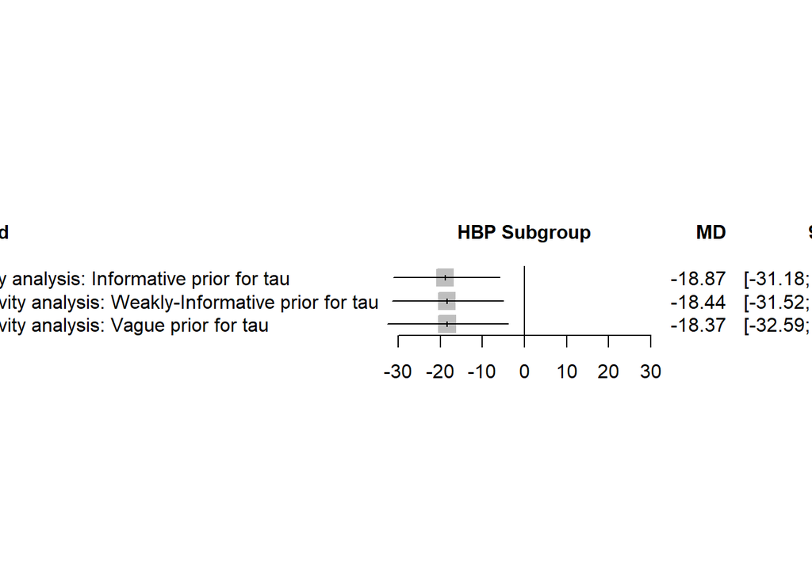

```r
# HBP (3 MODELS)
HBP_primary =
  metaadd(
    forest_data_MD,
    type = "random",
    TE = posterior_main$HBP_mean,
    lower = posterior_main$HBP_lower,
    upper = posterior_main$HBP_upper
  )

HBP_sensitivity_weak =
  metaadd(
    forest_data_MD,
    type = "random",
    TE = posterior_sens_weak$HBP_mean,
    lower = posterior_sens_weak$HBP_lower,
    upper = posterior_sens_weak$HBP_upper
  )

HBP_sensitivity_vague =
  metaadd(
    forest_data_MD,
    type = "random",
    TE = posterior_sens_vague$HBP_mean,
    lower = posterior_sens_vague$HBP_lower,
    upper = posterior_sens_vague$HBP_upper
  )

analyses = c("Primary analysis: Informative prior for tau",
             "Sensitivity analysis: Weakly-Informative prior for tau",
             "Sensitivity analysis: Vague prior for tau")

all_HBP =
  metabind(
    HBP_primary,
    HBP_sensitivity_weak,
    HBP_sensitivity_vague,
    name = analyses)

forest(all_HBP,
      smlab = "HBP Subgroup",
      leftcols = "studlab")
```

LBAP

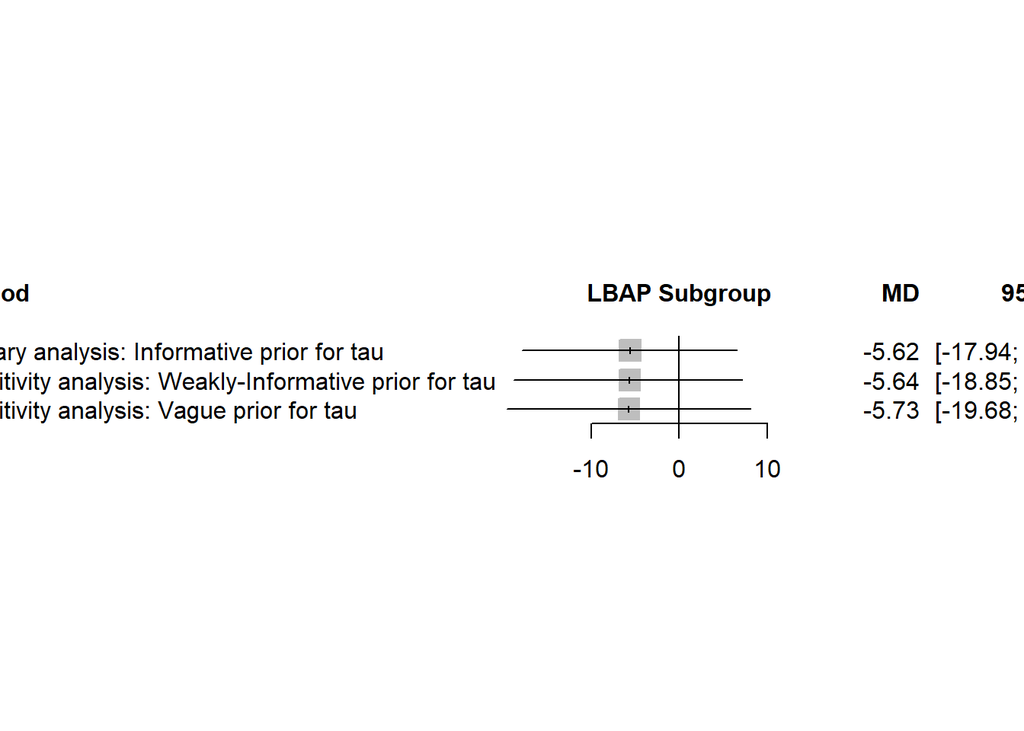

```r
# LBAP (3 MODELS)
LBAP_primary =
  metaadd(
    forest_data_MD,
    type = "random",
    TE = posterior_main$LBAP_mean,
    lower = posterior_main$LBAP_lower,
    upper = posterior_main$LBAP_upper
  )
LBAP_sensitivity_weak =
  metaadd(
    forest_data_MD,
    type = "random",
    TE = posterior_sens_weak$LBAP_mean,
    lower = posterior_sens_weak$LBAP_lower,
    upper = posterior_sens_weak$LBAP_upper
  )

LBAP_sensitivity_vague =
  metaadd(
    forest_data_MD,
    type = "random",
    TE = posterior_sens_vague$LBAP_mean,
    lower = posterior_sens_vague$LBAP_lower,
    upper = posterior_sens_vague$LBAP_upper
  )


analyses = c("Primary analysis: Informative prior for tau",
             "Sensitivity analysis: Weakly-Informative prior for tau",
             "Sensitivity analysis: Vague prior for tau")
all_LBAP =
  metabind(
    LBAP_primary,
    LBAP_sensitivity_weak,
    LBAP_sensitivity_vague,
    name = analyses
  )
forest(all_LBAP,
       smlab = "LBAP Subgroup",
       leftcols = "studlab")
```

Overall

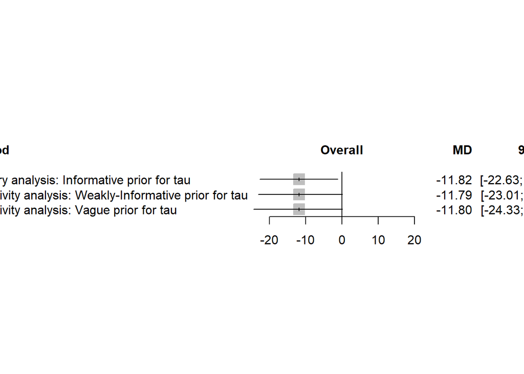

```r
overall_samples <- model_qrs_primary$rposterior(n = 10000, tau.sample = FALSE)

overall_summary <- mean_hdi(overall_samples)

overall_samples_sens_weak =
  weakly_sensitivity_overall_model$rposterior(n = 10000, tau.sample = FALSE) |>
  mean_hdi()

overall_samples_sens_vague =
  vague_sensitivity_overall_model$rposterior(n = 10000, tau.sample = FALSE) |>
  mean_hdi()

overall_primary =
  metaadd(
    forest_data_MD,
    type = "random",
    TE = overall_summary_qrs$y,
    lower = overall_summary_qrs$ymin,
    upper = overall_summary_qrs$ymax
  )

overall_sensitivity_weak =
  metaadd(
    forest_data_MD,
    type = "random",
    TE = overall_samples_sens_weak$y,
    lower = overall_samples_sens_weak$ymin,
    upper = overall_samples_sens_weak$ymax
  )

overall_sensitivity_vague =
  metaadd(
    forest_data_MD,
    type = "random",
    TE = overall_samples_sens_vague$y,
    lower = overall_samples_sens_vague$ymin,
    upper = overall_samples_sens_vague$ymax
  )

analyses = c("Primary analysis: Informative prior for tau",
             "Sensitivity analysis: Weakly-Informative prior for tau", "Sensitivity analysis: Vague prior for tau")

all_overall =
  metabind(
    overall_primary,
    overall_sensitivity_weak,
    overall_sensitivity_vague,
    name = analyses)

forest(all_overall,
       smlab = "Overall",
       leftcols = "studlab")
```